# project1

```python
import numpy as np
import librosa
import soundfile as sf
from scipy.signal import convolve
from matplotlib import pyplot as plt
from scipy.fft import fft
```

## Applying a filter to a vowel

```python
x, _ = librosa.load('./steadyStateVowel.wav', sr=16000)
f = np.array([-1, 1])
y = np.convolve(x, f)
```

```python
difference_equation = lambda x: np.array([x[0]] + [x[i] - x[i-1] for i in range(1, len(x))])
diff = np.append(difference_equation(x), -x[len(x)-1])
print(sum(diff - y))
```

```
0.0
```

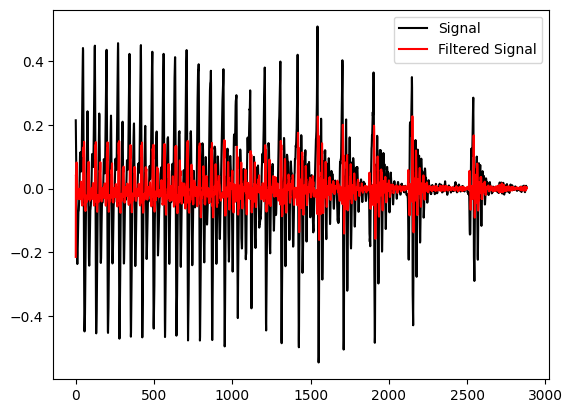

```python
plt.plot(x, color='black', label='Signal')
plt.plot(y, color='red', label='Filtered Signal')
plt.legend()
plt.show()
```

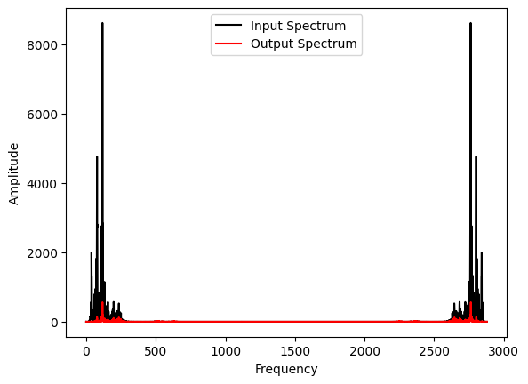

```python
input_spectrum = np.abs(fft(x))**2
output_spectrum = np.abs(fft(y))**2

# Plot the input and output spectra
plt.plot(input_spectrum, color='black', label='Input Spectrum')
plt.plot(output_spectrum, color='red', label='Output Spectrum')
plt.xlabel('Frequency')
plt.ylabel('Amplitude')
plt.legend()
plt.show()
```

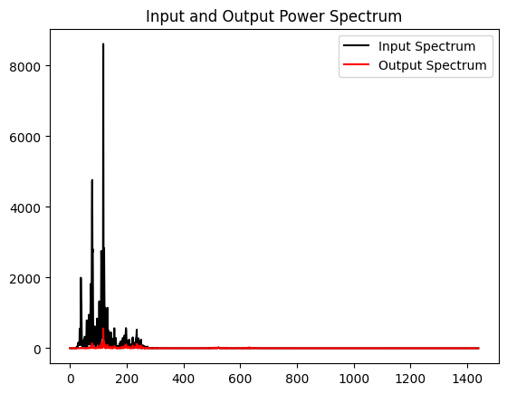

```python
cropped_input = len(input_spectrum)//2
cropped_output = len(output_spectrum)//2

plt.plot(input_spectrum[:cropped_input], color='black', label='Input Spectrum')
plt.plot(output_spectrum[:cropped_output], color='red', label='Output Spectrum')
plt.legend()
plt.title('Input and Output Power Spectrum')
```

When we apply to the Digital Fourier Transform directly to an entire sentence, the DFT treats the entire sentence as a single entity. This means that it assumes the signal is stationary across the entire duration of the sentence. The result would not be able to be analyzed in any meaningful way. The Short Time Fourier Transform analyzes the signal in windows, where each window has the Fourier Transform applied individually. This makes the STFT more suitable for analyzing signals with changing characteristics, like entire sentences.

Compared to the unfiltered version of the steady state vowel, the filtered version sounds tinny. This is often the result of a high-pass filter, which filters out low frequencies and passes through high frequencies. This makes sense given our filter, because if there is not a big difference between $x[n]$ and $x[n-1]$ because they are both small (thus, low frequency), the power will be small. However, if there is a big difference between $x[n]$ and $x[n-1]$, where one is a high frequency and one is low, the power will be large. So this type of filter emphasizes big differences in frequency and de-emphasizes small differences in frequency. High frequencies are thus emphasized and low frequencies are de-emphasized.

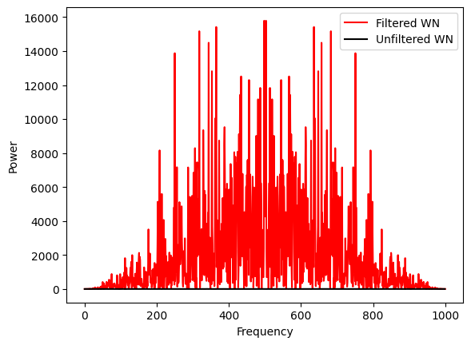

```python
sf.write('test.wav', y, samplerate=16000)

n_samples = 1000
white_noise = np.random.normal(0, 1, n_samples)
filtered_white_noise = np.convolve(white_noise, f)
white_noise_spectrum = np.abs(fft(filtered_white_noise))**2

plt.plot(white_noise_spectrum, color='red', label='Filtered WN')
plt.plot(white_noise, color='black', label='Unfiltered WN')
plt.xlabel('Frequency')
plt.ylabel('Power')
plt.legend()
plt.show()
```

## STFT and Spectrograms

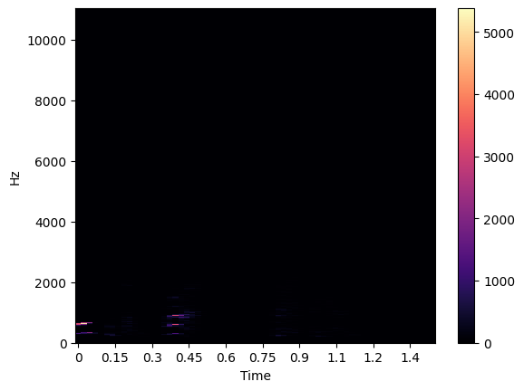

```python
x, _ = librosa.load('./sentence.wav', sr=16000)
spectrogram = np.abs(librosa.stft(x))**2

plt.figure()
librosa.display.specshow(spectrogram, x_axis='time', y_axis='linear')
plt.colorbar()
```

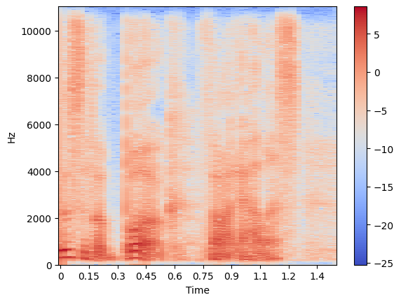

```python
logged_spectrogram = np.log(spectrogram)

plt.figure()
librosa.display.specshow(logged_spectrogram, x_axis='time', y_axis='linear')
plt.colorbar()
```

Taking the log of the power spectrogram makes it readable. The third dimension (amplitude) in the first graph had a wide range of possible values, and this large range made it difficult to distinguish the lower ends of the amplitude spectrum. However, this is where the information we want to view lies. By taking the log, we compress the range so that smaller variations are now distinguishable.

$\begin{aligned}\text{Number of samples} &= \text{window length} \times \text{sampling rate} \\ &= 0.025 \text{ seconds} \times 16000 \text{ samples per second } \\ &= 400 \text{ samples} \end{aligned} $

There are 400 samples in a 25 ms window.

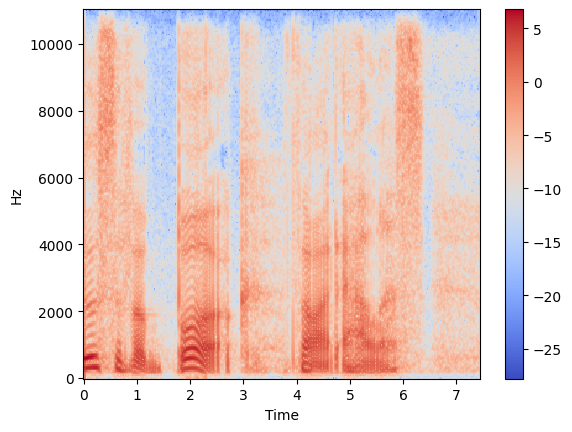

```python
win_spectrogram = np.log(np.abs(librosa.stft(x, win_length=400, n_fft=512))**2)

plt.figure()
librosa.display.specshow(win_spectrogram, x_axis='time', y_axis='linear')
plt.colorbar()
```

The previous log spectrogram does not have much time *or* frequency resolution at all. It appears choppy, as if the window length is too long to fully capture the minute changes in the signal. The second spectrogram is much clearer. We can see where there may be fricatives versus vowels versus no speech sounds.

I looked up the default settings for librosa.stft using the librosa documentation, and it appears the default window length is 93ms at a sample rate of 22050Hz. This is much longer than our window length is 25ms, which explains the lack of time resolution in the first spectrogram.

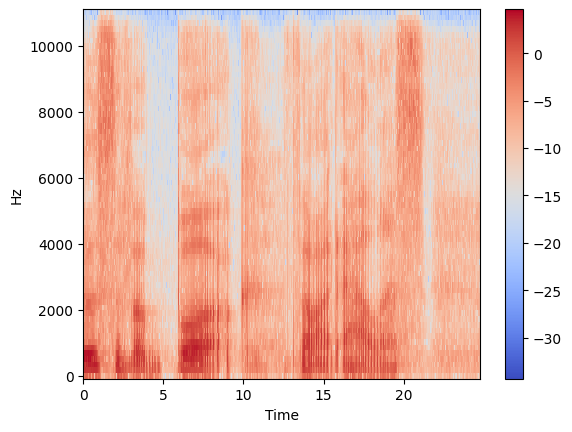

```python
win_spectrogram = np.log(np.abs(librosa.stft(x, win_length=120, n_fft=128))**2)

plt.figure()
librosa.display.specshow(win_spectrogram, x_axis='time', y_axis='linear')
plt.colorbar()
```

We lose the horizontal striations from the first spectrogram and gain vertical striations, which suggests an improvement in time resolution and a decrease in frequency resolution. Since we kept our sampling rate the same, the window length in seconds for the second spectrogram is

$120 = x \cdot 16000$

$x = 0.0075$

Because the window size is much smaller (~8ms vs 25ms), this spectrogram has better time resolution than the first spectrogram. When the window size is smaller, small variations between time frames are more easily captured. However, in gaining time resolution, we lose frequency resolution. Thus the two spectrograms show the two types of resolution we might care about when looking at a spectrogram -- frequency and time.

The first spectrogram (with a window size of 400) is narrowband, and the second spectrogram (with a window size of 120) is broadband. Narrowband spectrograms have better frequency resolution, resulting in horizontal bands that distinguish frequencies. We can see this in the first spectrogram. Broadband spectrograms have better time resolution, resulting in vertical bands that distinguish periods of time. We can see this in the second spectrogram.

## Speech Recognition with MFCCs

Here are three reasons why unsupervised learning may be preferred over supervised learning:

- If labeling is too expensive or otherwise unfeasible for the data that will be used in the learning algorithm, unsupervised learning may be more appropriate.
- Unsupervised learning is useful for identifying anomalies. Anomalies are not expected patterns and thus cannot be labeled ahead of time, so unsupervised learning is more appropriate.
- Clustering is an unsupervised learning technique that can be useful for exploring the structure and nature of the data. This technique can be used to uncover previously unknown clusters. Since the clusters are not known beforehand, the data could not be labeled for the learning task, making this an appropriate use case for unsupervised learning.

```python
import glob
from sklearn.linear_model import LogisticRegression

zeroes = glob.glob('spoken_digits/0*')
ones = glob.glob('spoken_digits/1*')
```

```python
def get_mfcc(input):
    output = []
    for file in input:
        x, _ = librosa.load(file)
        mfcc = librosa.feature.mfcc(y=x, sr=16000, n_mfcc=8, n_fft=512, win_length=400, hop_length=160)
        output.append(mfcc)

    return output

zeroes_mfcc = get_mfcc(zeroes)
ones_mfcc = get_mfcc(ones)

print(len(zeroes_mfcc))
print(len(ones_mfcc))
```

```
144
146
```

After some experimentation, I chose the frame number $21$. It is far enough from the beginning of the files to not have some instances of silence, and it is close to the initial sounds of each word, which are very different acoustically.

```python
zeroes_frames = [np.expand_dims(mfcc[:, 21], axis=0) for mfcc in zeroes_mfcc]
ones_frames = [np.expand_dims(mfcc[:, 21], axis=0) for mfcc in ones_mfcc]

X = np.concatenate(zeroes_frames + ones_frames, axis=0)

y = np.array([0] * len(zeroes_frames) + [1] * len(ones_frames))

print(X.shape)
print(y.shape)
```

```
(290, 8)
(290,)
```

```python
model = LogisticRegression(random_state=0, max_iter=1000).fit(X,y)
```

```python
model.score(X,y)
```

```
1.0
```

My model is performing with a 1.0 score, meaning that it never misclassifies any of the zeroes or ones. I experimented with some other frame numbers before finding this model, some near 0 and some near 35. The frame numbers close to 0 were very poor, while the frame numbers closer to 35 were near 1.0. The frame numbers close to 0 were likely picking up differences in speech onset time, which do not help with classification. The frame numbers closer to 35 were likely picking up differences in formants between the vowels. This is helpful for classification but not as helpful as the difference between a fricative and a liquid.